# ARIMA Model | Oil Price by Month

To predict future oil prices, we begin by applying systematic ARIMA modeling steps. In the [Exploratory Data Analisis | Oil Price](https://mazuckerberg.georgetown.domains/DSAN_5600/5_EDA/5_oil_price_month.html) section transformed the raw data into a stationary time series using first difference. Subsequently, the resulting ACF and PACF plots provide a visual representation of the autocorrelation structure within the resulting time series.

### Autocorrelation Plots

**Plot**

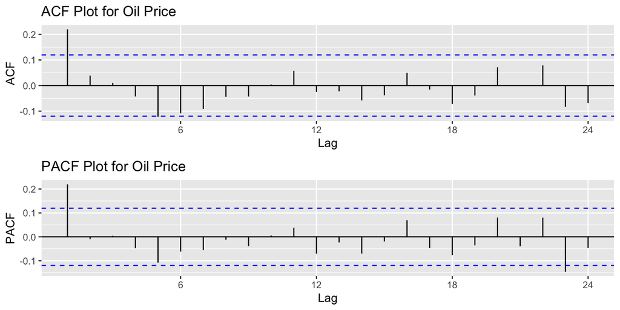

```r
# Import dataset
ts_oil_price <- read_csv('../data/ts_oil_price_monthly.csv')

# Create time series
ts_oil_price<-ts(ts_oil_price$x,star=decimal_date(as.Date("2000-08-31",format = "%Y-%m-%d")),frequency = 12)

# ACF Plot
acf_plot <- ggAcf(diff(ts_oil_price), main="ACF Plot for Oil Price")

# PACF Plot
pacf_plot <- ggPacf(diff(ts_oil_price), main="PACF Plot for Oil Price")

# Arrange Plots
grid.arrange(acf_plot, pacf_plot, nrow=2)
```

### Parameters Selection

To identify the optimal parameters for our model, we performed an analysis of the ACF and PACF plots. The ACF plot showed autocorrelation at lag 5, while the PACF plot showed autocorrelation at lag 1. Therefore, we selected the following parameters for the ARIMA model:

$p=1$

$d=1$

$q=5$

To validate our choices, we used the auto.arima() function, which resulted in a model with parameters (0,1,1). This comprehensive approach ensures that our ARIMA model is fine-tuned to capture the underlying patterns in the time series data, thereby improving its predictive accuracy.

**Parameters**

**Model Parameter Assesing**

```r
# Assigned time series to variable used in the algorithm
xt <- ts_oil_price

# PACF plot parameter selection
p_value <- 2

# Number of differences
d_value <- 2

# ACF plot parameter selection
q_value <- 6

# Initialize variable
i <- 1

# Initialize variable
temp <- data.frame()

# Calculate number of rows
rows <- p_value*d_value*q_value

#
ls <- matrix(rep(NA,6*rows),nrow=rows)

# Parameter testing loop
for (p in 1:p_value+1)
{
  for(q in 1:q_value+1)
  {
    for(d in 1:d_value)
    {

      #if(p-1+d+q-1<=8) #usual threshold
      #{

        model<- Arima(xt,order=c(p-1,d-1,q-1),include.drift=TRUE)
        ls[i,]= c(p-1,d-1,q-1,model$aic,model$bic,model$aicc)
        i=i+1
        #print(i)

      #}

    }
  }
}

temp <- as.data.frame(ls)

names(temp) <- c("p","d","q","AIC","BIC","AICc")

#temp
#knitr::kable(temp)
```

```
Minimum AIC:
```

```
   p d q       AIC       BIC      AICc
18 2 1 3 -107.1233 -81.98642 -106.6926
```

```
Minimum BIC:
```

```
  p d q       AIC       BIC      AICc
2 1 1 1 -103.5327 -89.16876 -103.3806
```

```
Minimum AICc:
```

```
   p d q       AIC       BIC      AICc
18 2 1 3 -107.1233 -81.98642 -106.6926
```

**auto.arima()**

**auto.arima()**

```r
auto.arima(xt)
```

```
Series: xt
ARIMA(0,1,1)

Coefficients:
         ma1
      0.2150
s.e.  0.0578

sigma^2 = 0.03883:  log likelihood = 55.52
AIC=-107.05   AICc=-107   BIC=-99.86
```

### Diagnostics

Evaluating the model selection criteria, it is clear that both the AIC and AICc converge on the model (2, 1, 3) as the optimal choice, while the BIC favors the model (1, 1, 1). To fully evaluate their performance, we carefully examined the diagnostic plots for each model along with the auto.arima() results. When compared, model (1, 1, 1) emerges as the better choice. The standardized residuals show an apparently random pattern, the Q-Q plot suggests a tendency toward normality, and all Ljung box statistics exceed the significance level, indicating no autocorrelation.

**auto.arima()**

**Model Diagnostics - parameters auto.arima()**

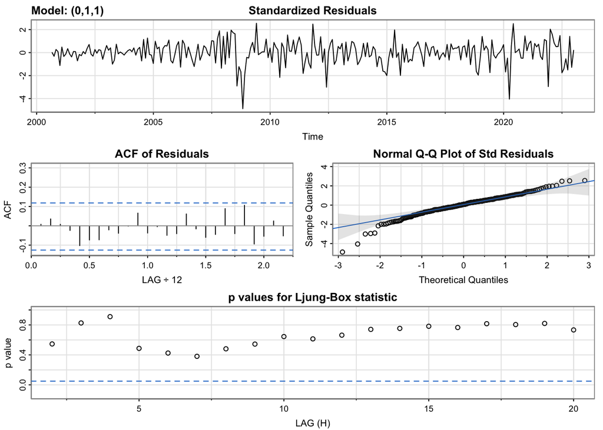

```r
p_autoarima <- 0
d_autoarima <- 1
q_autoarima <- 1

# Model diagnostics for best AIC
model_output <- capture.output(sarima(xt, p_autoarima, d_autoarima, q_autoarima))
```

**AIC**

**Model Diagnostics - parameters with best AIC**

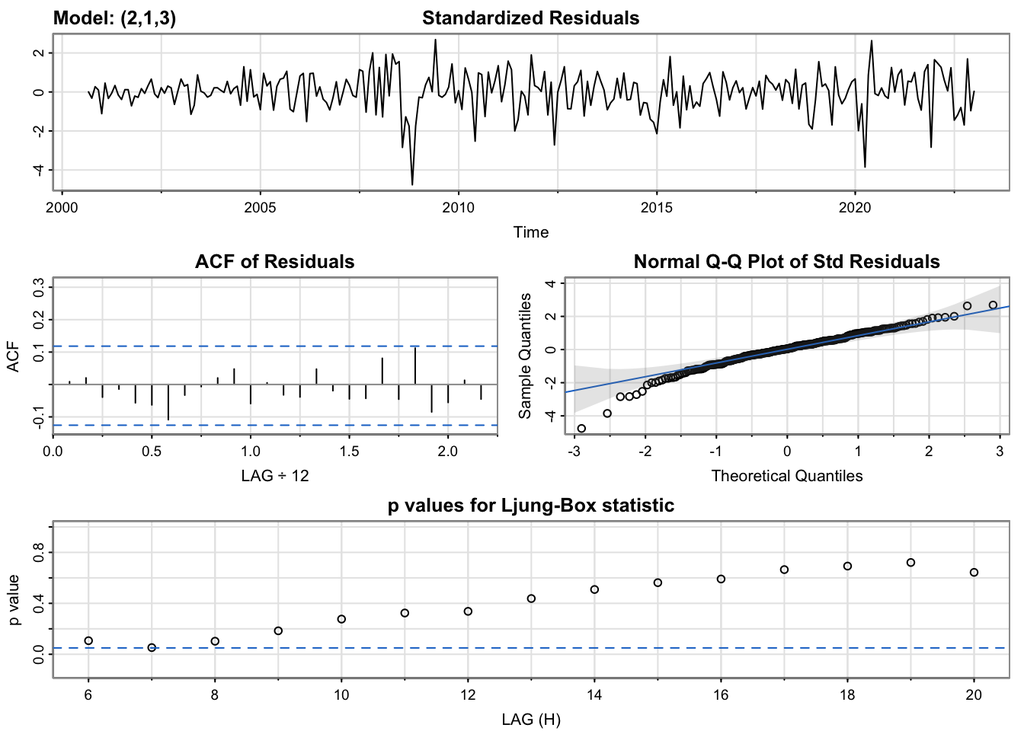

```r
AIC <- temp[which.min(temp$AIC),]

p1 <- AIC$p
d1 <- AIC$d
q1 <- AIC$q

# Model diagnostics for best AIC
model_output <- capture.output(sarima(xt, p1, d1, q1))
```

**BIC**

**Model Diagnostics - parameters with best BIC**

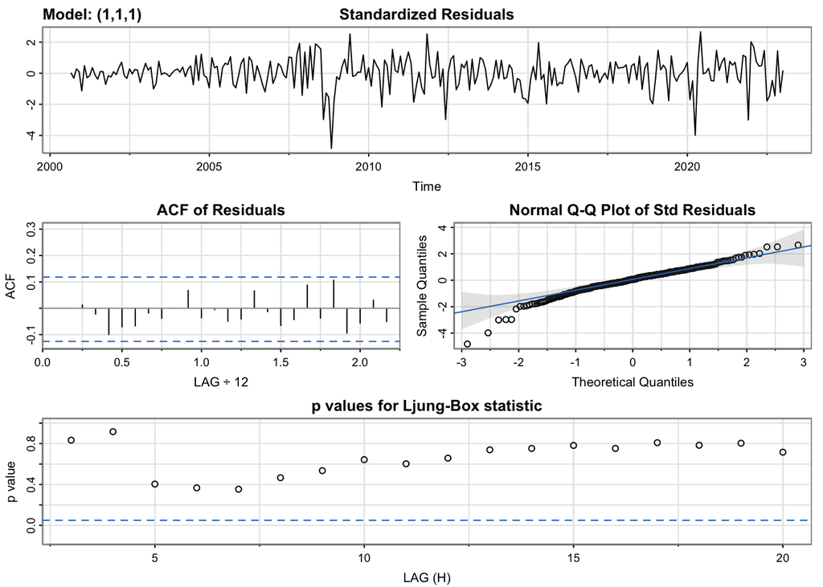

```r
BIC <- temp[which.min(temp$BIC),]

p2 <- BIC$p
d2 <- BIC$d
q2 <- BIC$q

# Model diagnostics for best BIC
model_output <- capture.output(sarima(xt, p2, d2, q2))
```

### Fit Model

Analysis of the fit line plotted against the original time series for the ARIMA model shows a similarity, indicating a robust fit between the model and the actual data. This close fit provides confidence in the model’s ability to generate accurate predictions.

**Model Fit Plot**

**Model Fitting**

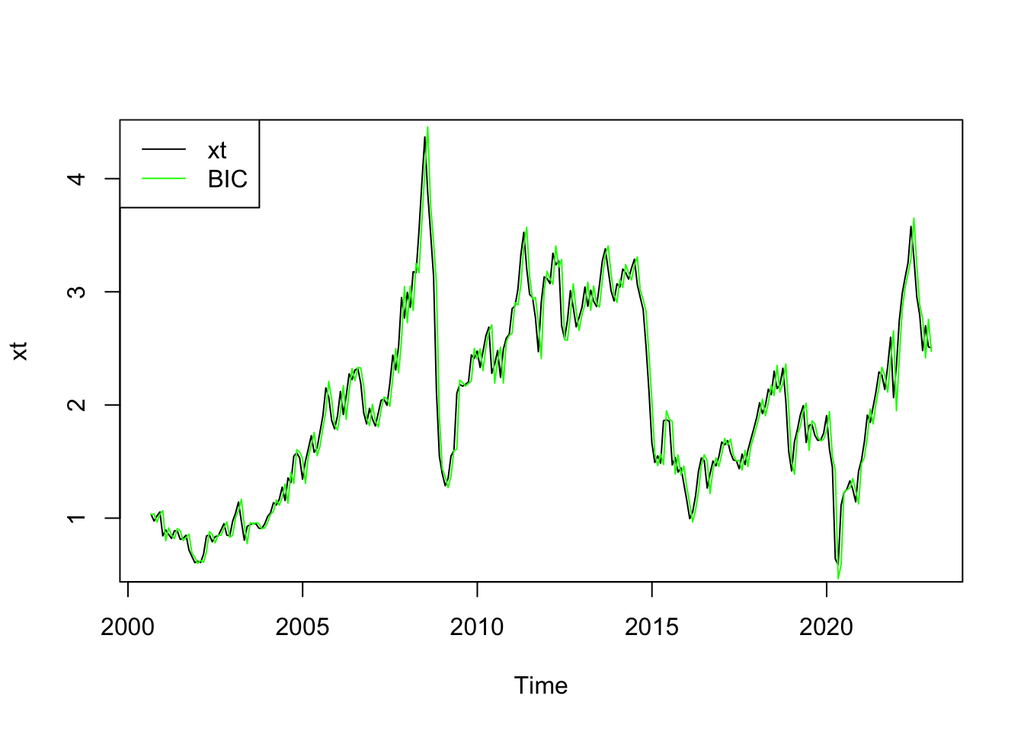

```r
best_model <- temp[which.min(temp$BIC),]

p <- best_model$p
d <- best_model$d
q <- best_model$q


model <- Arima(xt,order=c(p, d, q),include.drift = TRUE)

plot(xt, col="black")
lines(fitted(model), col="green")
legend(x = "topleft", legend = c("xt", "BIC"), col = c("black", "green"), lty = 1)
```

**Model Summary**

**Fitted Model Summary**

```r
fit <- Arima(xt, order=c(p, d, q))
summary(fit)
```

```
Series: xt
ARIMA(1,1,1)

Coefficients:
         ar1     ma1
      0.1761  0.0455
s.e.  0.2840  0.2890

sigma^2 = 0.03892:  log likelihood = 55.7
AIC=-105.41   AICc=-105.31   BIC=-94.63

Training set error measures:
                    ME      RMSE       MAE        MPE     MAPE      MASE
Training set 0.0043197 0.1961766 0.1462777 -0.2130352 7.974124 0.2664199
                     ACF1
Training set 0.0004676504
```

### Equation

$$\begin{equation}
(1 - 0.1761B)(1 - B)(y_t - \mu) = (1 + 0.0455a_t)
\end{equation}$$

### Forecast

The chart below illustrates the forecasts and shows a consistent trajectory for oil prices. Comparison of the forecast plot with benchmark models shows alignment with the naive model, while deviations are evident when compared with the mean and seasonal naive models.

Improvements in model accuracy can be pursued through parameter adjustments or by exploring more sophisticated models, such as VAR or ARIMAX, which incorporate exogenous variables for a comprehensive analysis.

**Forecast plot**

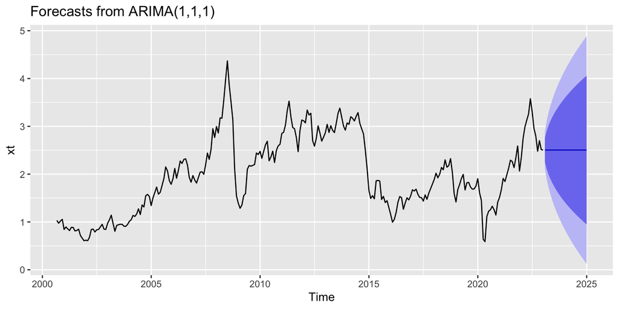

```r
forecast_fit <- forecast(fit,24)

plot1 <- autoplot(forecast_fit)

plot1
```

### Benchmark Models

**Benchmark Models Plot**

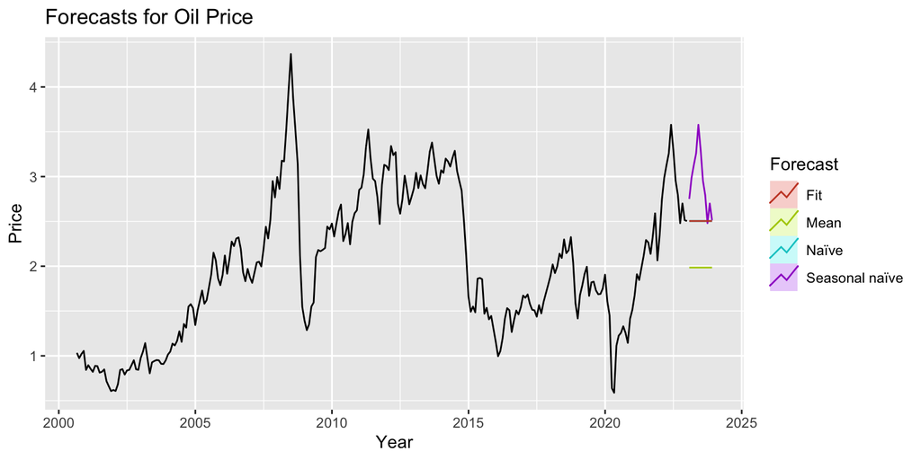

```r
autoplot(xt) +
  autolayer(meanf(xt, h=11),
            series="Mean", PI=FALSE) +
  autolayer(naive(xt, h=11),
            series="Naïve", PI=FALSE) +
  autolayer(snaive(xt, h=11),
            series="Seasonal naïve", PI=FALSE) +
  autolayer(forecast(forecast_fit, h=11),
            series="Fit", PI=FALSE) +
  ggtitle("Forecasts for Oil Price") +
  xlab("Year") + ylab("Price") +
  guides(colour=guide_legend(title="Forecast"))
```